# Project 1

# female

agegrp DMDMARTLX  
(29, 40] Married 275 Never married 101 Living whit partner 78 Divorced 24 Separated 12 Widowed 3 Refused 1

# allages

Married 2780 Never married 1004 Divorced 579 Living whit partner 527 Widowed 396 Separated 186 Refused 2 Name: DMDMARTLX, dtype: int64

**Q1c.** Repeat part b for the men.

## Question 2

```python
# insert your code here
daf = da.loc[da['RIAGENDR'] == 1]
daf.head()
```

|  | SEQN | ALQ101 | ALQ110 | ALQ130 | SMQ020 | RIAGENDR | RIDAGEYR | RIDRETH1 | DMDCITZN | DMDEDUC2 | ... | BMXWT | BMXHT | BMXBMI | BMXLEG | BMXARML | BMXARMC | BMXWAIST | HIQ210 | DMDMARTLX | RIAGENDRX |
| --- | --- | --- | --- | --- | --- | --- | --- | --- | --- | --- | --- | --- | --- | --- | --- | --- | --- | --- | --- | --- | --- |
| 0 | 83732 | 1.0 | NaN | 1.0 | 1 | 1 | 62 | 3 | 1.0 | 5.0 | ... | 94.8 | 184.5 | 27.8 | 43.3 | 43.6 | 35.9 | 101.1 | 2.0 | Married | Male |
| 1 | 83733 | 1.0 | NaN | 6.0 | 1 | 1 | 53 | 3 | 2.0 | 3.0 | ... | 90.4 | 171.4 | 30.8 | 38.0 | 40.0 | 33.2 | 107.9 | NaN | Divorced | Male |
| 2 | 83734 | 1.0 | NaN | NaN | 1 | 1 | 78 | 3 | 1.0 | 3.0 | ... | 83.4 | 170.1 | 28.8 | 35.6 | 37.0 | 31.0 | 116.5 | 2.0 | Married | Male |
| 6 | 83741 | 1.0 | NaN | 8.0 | 1 | 1 | 22 | 4 | 1.0 | 4.0 | ... | 76.6 | 165.4 | 28.0 | 38.8 | 38.0 | 34.0 | 86.6 | NaN | Never married | Male |
| 8 | 83743 | NaN | NaN | NaN | 2 | 1 | 18 | 5 | 1.0 | NaN | ... | 72.4 | 166.1 | 26.2 | NaN | NaN | NaN | NaN | 2.0 | NaN | Male |

5 rows × 30 columns

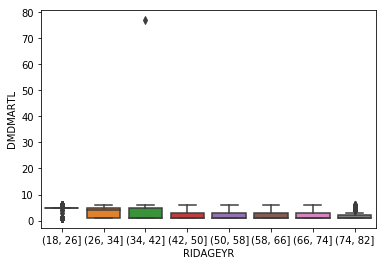

```python
k = pd.cut(daf['RIDAGEYR'], bins=[18, 26, 34, 42, 50, 58, 66, 74, 82])
plot = sns.boxplot(x = k, y = daf['DMDMARTL'])
```

**Q2a.** Comment on the trends that you see in this series of marginal distributions.

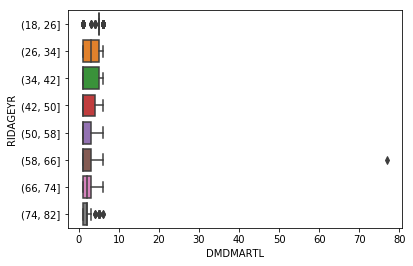

```python
# insert your code here
dam = da.loc[da['RIAGENDR'] == 2]
dam.head()
k = pd.cut(dam['RIDAGEYR'], bins=[18, 26, 34, 42, 50, 58, 66, 74, 82])
plot = sns.boxplot(y = k, x = dam['DMDMARTL'])
```

**Q2c.** Comment on any notable differences that you see when comparing these results for females and for males.

## Question 3

Construct a histogram of the distribution of heights using the BMXHT variable in the NHANES sample.

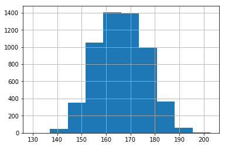

```python
# insert your code here
da['BMXHT'].dropna().hist()
```

**Q3a.** Use the `bins` argument to [distplot](https://seaborn.pydata.org/generated/seaborn.distplot.html) to produce histograms with different numbers of bins. Assess whether the default value for this argument gives a meaningful result, and comment on what happens as the number of bins grows excessively large or excessively small.

**Q3b.** Make separate histograms for the heights of women and men, then make a side-by-side boxplot showing the heights of women and men.

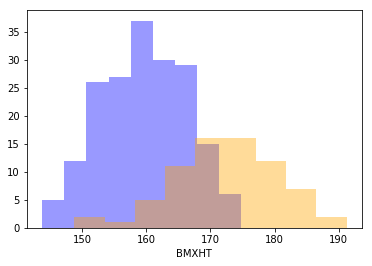

```python
# insert your code here

female = da[da['RIAGENDR'] == 2]
male=da[da['RIAGENDR']==1]
male.dropna(inplace=True)
female.dropna(inplace=True)
# female['BMXHT'].hist()
# male['BMXHT'].hist()

sns.distplot(female['BMXHT'],kde=False,color='blue')
sns.distplot(male['BMXHT'],kde=False,color='orange')
plt.show()
```

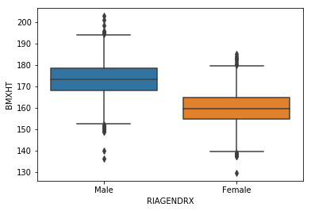

```python
da['BMXHT'].dropna(inplace=True)
# d1=da[['RIAGENDRX','BMXHT']]
sns.boxplot(x="RIAGENDRX",y="BMXHT",data=da)
```

**Q3c.** Comment on what features, if any are not represented clearly in the boxplots, and what features, if any, are easier to see in the boxplots than in the histograms.

## Question 4

Make a boxplot showing the distribution of within-subject differences between the first and second systolic blood pressure measurents (BPXSY1 and BPXSY2).

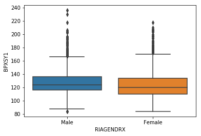

```python
# insert your code here
da.dropna(inplace=True,subset=['BPXSY2','BPXSY1'])
sns.boxplot(x="RIAGENDRX",y="BPXSY1",data=da)
```

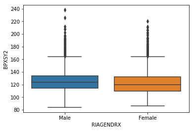

```python
sns.boxplot(x="RIAGENDRX",y="BPXSY2",data=da)
```

**Q4a.** What proportion of the subjects have a lower SBP on the second reading compared to the first?

```python
# insert your code here
# da["BPXSY2"]<da["BPXSY1"]
da.dropna(inplace=True,subset=['BPXSY2','BPXSY1'])
len(da[da["BPXSY2"]<da["BPXSY1"]])/len(da["BPXSY2"])
da.count()
```

```
SEQN         5369
ALQ101       4942
ALQ110       1624
ALQ130       3223
SMQ020       5369
RIAGENDR     5369
RIDAGEYR     5369
RIDRETH1     5369
DMDCITZN     5368
DMDEDUC2     5120
DMDMARTL     5120
DMDHHSIZ     5369
WTINT2YR     5369
SDMVPSU      5369
SDMVSTRA     5369
INDFMPIR     4809
BPXSY1       5369
BPXDI1       5369
BPXSY2       5369
BPXDI2       5369
BMXWT        5319
BMXHT        5325
BMXBMI       5315
BMXLEG       5063
BMXARML      5136
BMXARMC      5136
BMXWAIST     5085
HIQ210       4429
DMDMARTLX    5120
RIAGENDRX    5369
dtype: int64
```

**Q4b.** Make side-by-side boxplots of the two systolic blood pressure variables.

```python
# insert your code here
```

**Q4c.** Comment on the variation within either the first or second systolic blood pressure measurements, and the variation in the within-subject differences between the first and second systolic blood pressure measurements.

## Question 5

Construct a frequency table of household sizes for people within each educational attainment category (the relevant variable is DMDEDUC2). Convert the frequencies to proportions.

```python
# insert your code here

da.groupby('DMDEDUC2')['DMDHHSIZ'].value_counts()
```

[output not shown]

**Q5a.** Comment on any major differences among the distributions.

**Q5b.** Restrict the sample to people between 30 and 40 years of age. Then calculate the median household size for women and men within each level of educational attainment.

```python
# insert your code here

between = da.loc[(da['RIDAGEYR'] > 29) & (da['RIDAGEYR'] < 41)]

between
```

[output not shown]

## Question 6

The participants can be clustered into "maked variance units" (MVU) based on every combination of the variables SDMVSTRA and SDMVPSU. Calculate the mean age (RIDAGEYR), height (BMXHT), and BMI (BMXBMI) for each gender (RIAGENDR), within each MVU, and report the ratio between the largest and smallest mean (e.g. for height) across the MVUs.

```python
# insert your code here
```

**Q6a.** Comment on the extent to which mean age, height, and BMI vary among the MVUs.

**Q6b.** Calculate the inter-quartile range (IQR) for age, height, and BMI for each gender and each MVU. Report the ratio between the largest and smalles IQR across the MVUs.

```python
# insert your code here
```

**Q6c.** Comment on the extent to which the IQR for age, height, and BMI vary among the MVUs.